# Indirect effects in DC-TAP-seq screens

Andreas R. Gschwind

September 11, 2025

```r
library(tidyverse)
library(ggExtra)
library(cowplot)
library(DT)
```

## Goal

We empirically estimated the indirect effect rates in CRISPR experiments by testing distal elements (DE) for trans-acting effects on genes on other chromosomes. By subtracting the indirect effect rates from the observed cis positive rates, we modeled the expected direct effects rate as a function of distance to TSS. Using the estimated indirect ($r_{\text{indirect}}$) and direct effects rates as function of distance ($r_{\text{direct}}(d)$), we calculated a probability of each CRISPR DE-gene pair to be the result of a direct effect as a function of distance to TSS:

$$p_{\text{direct}}(d) =
\frac{r_{\text{direct}}(d)}{r_{\text{direct}}(d) +
r_{\text{indirect}}}$$

Refer to the “Computing the probability that DE-G pair is a direct versus indirect effect” Methods section of the manuscript for more information on this approach. Here we analyze the direct and indirect rates in the K562 and WTC11 DC-TAP-seq screens to reproduce the plots shown in **Figure 4** and **Extended Data Figure 3**.

## Used data

This analysis uses the output of the [**CRISPR indirect effects**](https://github.com/EngreitzLab/CRISPR_indirect_effects) analysis workflow as input. Probabilities of direct effects for K562 and WTC11 DC-TAP-seq experiments calculated by this workflow can be found in Table S3.

```r
# output of the direct vs. indirect effects workflow (adjust via params as needed)
indirect_effects_dir <- params$indirect_effects_dir

# Table S3
table_s3_file <- params$table_s3_file

# output directory for generated plots
outdir <- params$outdir
dir.create(outdir, showWarnings = FALSE, recursive = TRUE)
```

First we load all requied input files from the indirect effects analysis:

```r
# load cis and trans positive rates from indirect effects analyses
cis_rates <- read_tsv(file.path(indirect_effects_dir, "cis_positive_hit_rates.tsv"),
                      show_col_types = FALSE)
trans_rates <- read_tsv(file.path(indirect_effects_dir, "trans_positive_hit_rates.tsv"),
                        show_col_types = FALSE)

# extract data on DC-TAP-seq screens only
cis_rates   <- filter(cis_rates,   dataset %in% c("K562_DC_TAPseq", "WTC11_DC_TAPseq"))
trans_rates <- filter(trans_rates, dataset %in% c("K562_DC_TAPseq", "WTC11_DC_TAPseq"))

# load DC-TAP-seq results in Table S3
results <- read_tsv(table_s3_file, show_col_types = FALSE)

# add 'Dataset' column
results <- mutate(results, Dataset = paste0(cell_type, "_DC_TAPseq"))

# load direct effects models
direct_effect_models <- readRDS(file.path(indirect_effects_dir, "direct_effect_models/direct_effects_model.rds"))
```

## Expected indirect hits

Calculate the percentage and number of indirect effects in cis DE-gene analyses for effects with a negative, positive or any direction on target gene expression in the K562 and WTC11 screens.

First, get the expected number and percentage of expected indirect effects in the cis DE-gene analysis.

```r
# filter cis hit rates to within 1Mb only
cis_rates <- filter(cis_rates, mean_dist < 1e6)

# count the number of cis pairs and hits per dataset across all distances and convert to long format
effect_rates <- cis_rates %>%
  group_by(dataset) %>%
  summarize(total_pairs = sum(total_pairs),
            significant_pairs = sum(significant_pairs),
            negative_pairs = sum(negative_pairs),
            positive_pairs = sum(positive_pairs),
            .groups = "drop") %>%
  pivot_longer(cols = -c(dataset, total_pairs), names_to = "effect_direction",
               values_to = "significant_cis_pairs") %>%
  select(dataset, effect_direction, tested_cis_pairs = total_pairs, significant_cis_pairs) %>%
  mutate(effect_direction = sub("_pairs", "", effect_direction)) %>%
  mutate(effect_direction = if_else(effect_direction == "significant", true = "any",
                                    false = effect_direction))

# convert indirect (trans) hits to long format and add to cis rates
effect_rates <- trans_rates %>%
  select(dataset, tested_indirect_pairs = total_pairs, any = significant_pairs,
         negative = negative_pairs, positive = positive_pairs) %>%
  pivot_longer(cols = -c(dataset, tested_indirect_pairs), names_to = "effect_direction",
               values_to = "significant_indirect_pairs") %>%
  left_join(effect_rates, ., by = c("dataset", "effect_direction"))

# convert indirect (trans) hit rates to long format and add to cis rates
effect_rates <- trans_rates %>%
  select(dataset, any = positive_rate_significant, negative = positive_rate_negative,
         positive = positive_rate_positive) %>%
  pivot_longer(cols = -dataset, names_to = "effect_direction",
               values_to = "indirect_effects_rate") %>%
  left_join(effect_rates, ., by = c("dataset", "effect_direction"))

# compute number and percentage of expected indirect effects
effect_rates <- effect_rates %>%
  mutate(expected_indirect_cis_pairs = round(tested_cis_pairs * indirect_effects_rate)) %>%
  mutate(percent_indirect_cis_pairs = expected_indirect_cis_pairs / significant_cis_pairs)
```

Next, compute how many of the final, filtered DE-gene pairs can be expected to be from indirect effects based on the estimated percentage of indirect effects among all significant cis DE-gene pairs.

```r
# extract 'valid' random screen pairs within 1Mb
random_pairs <- results %>%
  filter((significant_wo_pos_controls_20fdr | power_at_effect_size_25_wo_pos_controls_20fdr >= 0.8)) %>%
  filter(Random_DistalElement_Gene == TRUE) %>%
  filter(abs(distance_to_gencode_gene_TSS) <= 1e6)

# get filtered final number of significant pairs
final_significant_pairs <- random_pairs %>%
  group_by(Dataset) %>%
  summarize(any = sum(significant_wo_pos_controls_20fdr == TRUE),
            negative = sum(significant_wo_pos_controls_20fdr == TRUE & log_2_FC_effect_size <= 0),
            positive = sum(significant_wo_pos_controls_20fdr == TRUE & log_2_FC_effect_size > 0),
            .groups = "drop") %>%
  pivot_longer(cols = -Dataset, names_to = "effect_direction",
               values_to = "filtered_significant_cis_pairs")

# add to table with calculated effect rates
effect_rates <- left_join(effect_rates, final_significant_pairs,
                          by = c("dataset" = "Dataset", "effect_direction"))

# compute expected number of filtered pairs to be due to indirect effects based on
effect_rates <- effect_rates %>%
  mutate(expected_indirect_final_cis_pairs = round(filtered_significant_cis_pairs * percent_indirect_cis_pairs))
```

|  | dataset | effect_direction | tested_cis_pairs | significant_cis_pairs | tested_indirect_pairs | significant_indirect_pairs | indirect_effects_rate | expected_indirect_cis_pairs | percent_indirect_cis_pairs | filtered_significant_cis_pairs | expected_indirect_final_cis_pairs |
| --- | --- | --- | --- | --- | --- | --- | --- | --- | --- | --- | --- |
| 1 | K562_DC_TAPseq | any | 3218 | 35 | 65951 | 606 | 0.00918864005094691 | 30 | 0.8571428571428571 | 35 | 30 |
| 2 | K562_DC_TAPseq | negative | 3218 | 17 | 65951 | 197 | 0.00298706615517581 | 10 | 0.5882352941176471 | 17 | 10 |
| 3 | K562_DC_TAPseq | positive | 3218 | 18 | 65951 | 409 | 0.0062015738957711 | 20 | 1.111111111111111 | 18 | 20 |
| 4 | WTC11_DC_TAPseq | any | 3343 | 81 | 74500 | 1013 | 0.01359731543624161 | 45 | 0.5555555555555556 | 81 | 45 |
| 5 | WTC11_DC_TAPseq | negative | 3343 | 56 | 74500 | 443 | 0.00594630872483221 | 20 | 0.3571428571428572 | 56 | 20 |
| 6 | WTC11_DC_TAPseq | positive | 3343 | 25 | 74500 | 570 | 0.00765100671140939 | 26 | 1.04 | 25 | 26 |

## Direct vs indirect effects as function of distance

Next we show how the direct, indirect (trans) effect rates and probability of direct effects behave as functions of distance to TSS

#### Overall cis hit and indirect hit rates

```r
# reformat cis hit rates for plot
cis_rates_plot <- cis_rates %>%
  select(dataset, mean_dist, positive_rate_negative, positive_rate_positive) %>%
  pivot_longer(cols = -c(dataset, mean_dist), names_to = "effect_direction",
               values_to = "positive_rate") %>%
  mutate(cell_type = sub("_DC_TAPseq", "", dataset)) %>%
  mutate(effect_direction = str_to_title(sub("positive_rate_", "", effect_direction))) %>%
  mutate(effect_direction = factor(effect_direction))

# helper function to plot observed hit rates as function of distance to TSS
plot_observed_rates <- function(observed_rates, ylim) {
  ggplot(observed_rates, aes(x = mean_dist / 1e6, y = positive_rate, color = cell_type,
                    shape = effect_direction)) +
  geom_hline(yintercept = 0, linetype = "dashed", color = "gray") +
  geom_point() +
  labs(title = paste(unique(observed_rates$effect_direction), "effects on expression"),
       x = "Distance to TSS (Mb)",
       y = "Rate of observed effects", color = "Cell type", shape = "Direction of effect") +
  scale_color_manual(values = c(K562 = "#b00404", WTC11 = "#0202cc")) +
  scale_shape_manual(values = c(Negative = 19, Positive = 1), drop = FALSE) +
  scale_y_continuous(limits = ylim, labels = scales::percent) +
  theme_classic() +
  theme(legend.position = "top")
}

# plot observed hit rates for negative and positive effects on expression as function of distance
ylim <- c(NA, max(cis_rates_plot$positive_rate))
p_obs_neg <- plot_observed_rates(filter(cis_rates_plot, effect_direction == "Negative"), ylim = ylim)
p_obs_pos <- plot_observed_rates(filter(cis_rates_plot, effect_direction == "Positive"), ylim = ylim)
```

```r
# reformat trans hit rates for plot
trans_rates_plot <- trans_rates %>%
  select(dataset, positive_rate_negative, positive_rate_positive) %>%
  pivot_longer(cols = -dataset, names_to = "effect_direction", values_to = "positive_rate") %>%
  mutate(cell_type = sub("_DC_TAPseq", "", dataset)) %>%
  mutate(effect_direction = str_to_title(sub("positive_rate_", "", effect_direction)))

# helper function to plot indirect effects rates
plot_indirect_rates <- function(indirect_rates, ylim) {
  ggplot(indirect_rates, aes(x = "Other\nchromosomes\n(Rate of\nindirect effects)",
                             y = positive_rate,  color = cell_type, shape = effect_direction)) +
    geom_hline(yintercept = 0, linetype = "dashed", color = "gray") +
    geom_point() +
    scale_color_manual(values = c(K562 = "#b00404", WTC11 = "#0202cc")) +
    scale_shape_manual(values = c(Negative = 19, Positive = 1)) +
    scale_y_continuous(limits = ylim, labels = scales::percent) +
    theme_classic() +
    theme(legend.position = "none", axis.title.x = element_blank(),
          axis.line.y = element_blank(), axis.title.y = element_blank(),
          axis.text.y = element_blank(), axis.ticks.y = element_blank())
}

# plot indirect hit rates for negative and positive effects on expression
p_ind_neg <- plot_indirect_rates(filter(trans_rates_plot, effect_direction == "Negative"), ylim = ylim)
p_ind_pos <- plot_indirect_rates(filter(trans_rates_plot, effect_direction == "Positive"), ylim = ylim)
```

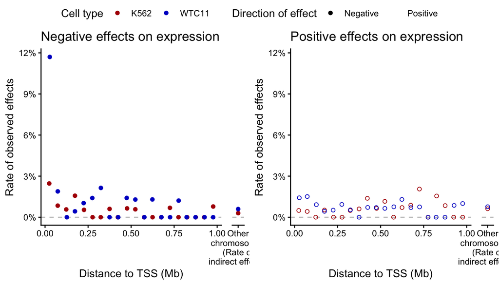

```r
# extract legend from one plot
legend <- get_legend(p_obs_neg)

# arrange all plots
plots <- plot_grid(
  p_obs_neg + theme(legend.position = "none"),
  p_ind_neg,
  p_obs_pos + theme(legend.position = "none"),
  p_ind_pos,
  nrow = 1, rel_widths = c(1, 0.1, 1, 0.1), align = "h"
)

# combine legend and plots into one figure
plot_grid(legend, plots, nrow = 2, rel_heights = c(0.1, 1))
```

#### Probability of direct effect

The overall cis and indirect hit rates are used to compute the probability of direct effects as described above. Note that at this stage we included results from additional CRISPR enhancer perturbation screens to compute the expected direct effects rate as function of TSS (see Methods).

This plot shows the probability of direct effects as function of distance to TSS for the K562 and WTC11 DC-TAP-seq screens.

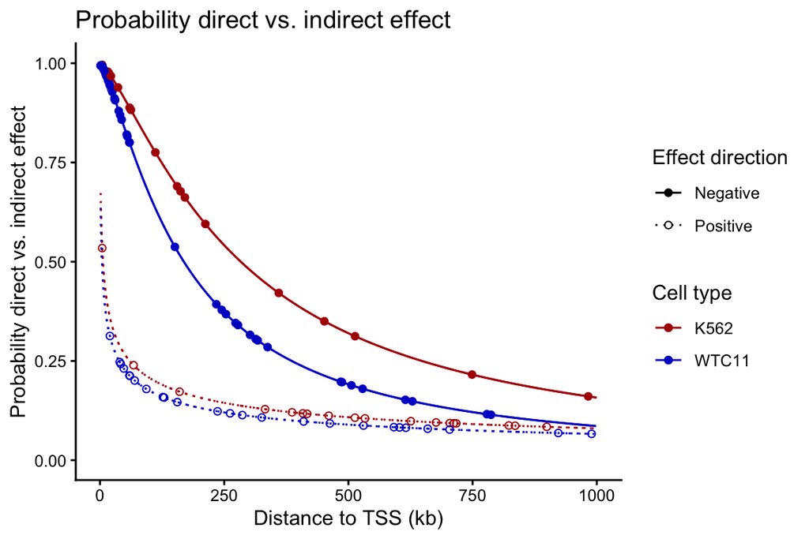

```r
# add effects direction label for each CRISPR E-G pair
random_pairs <- random_pairs %>%
  mutate(effect_direction = if_else(log_2_FC_effect_size <= 0, true = "Negative",
                                    false = "Positive"))

# select positive and negative indirect rates and convert to long format for plot
random_pairs_plot <- random_pairs %>%
  select(element_gene_pair_identifier_hg38, cell_type, dist_to_tss = distance_to_gencode_gene_TSS,
         Significant = significant_wo_pos_controls_20fdr, direct_vs_indirect_negative,
         direct_vs_indirect_positive, effect_direction) %>%
  pivot_longer(cols = c(direct_vs_indirect_negative, direct_vs_indirect_positive),
               names_to = "rate_type", values_to = "direct_vs_indirect") %>%
  mutate(rate_type = str_to_title(sub("direct_vs_indirect_", "", rate_type))) %>%
  mutate(label = paste0(cell_type, " (", rate_type, " effects)"))

# plot probability of direct effects as function of distance to TSS
ggplot(random_pairs_plot, aes(x = dist_to_tss / 1e3, y = direct_vs_indirect, color = cell_type,
                              linetype = rate_type, shape = effect_direction)) +
  geom_line() +
  geom_point(data = filter(random_pairs_plot, Significant == TRUE, effect_direction == "Negative",
                           rate_type == "Negative")) +
  geom_point(data = filter(random_pairs_plot, Significant == TRUE, effect_direction == "Positive",
                           rate_type == "Positive")) +
  labs(title = "Probability direct vs. indirect effect", x = "Distance to TSS (kb)",
       y = "Probability direct vs. indirect effect", color = "Cell type",
       linetype = "Effect direction", shape = "Effect direction") +
  scale_linetype_manual(values = c(Negative = 1, Positive = 3)) +
  scale_color_manual(values = c(K562 = "#b00404", WTC11 = "#0202cc")) +
  scale_shape_manual(values = c(Negative = 19, Positive = 1)) +
  scale_y_continuous(limits = c(0, 1)) +
  theme_classic()
```

## Properties of likely direct and indirect DE-gene pairs

Next we use the probability of direct effects to analyze properties of DE-gene pairs that are likely to be the result of direct or indirect effects. In these analyses we only look at the probability of direct effects for negative effects on gene expression (downregulation), because the K562 and WTC11 experiments were designed to target enhancers, which are expected to have a negative effect on target gene expression when perturbed.

#### Distance to TSS

```r
# function to predict the direct hit rate for a given distance using the fitted models for direct
# effects as function of distance to TSS
predict_direct_hit_rate <- function(models, new_data, type) {

  # get model for specified type
  fit <- models[[type]]

  # predict direct hit rate for provided distances and exponentiate to get back to original scale
  predicted_log_direct_rate <- predict(fit, newdata = new_data)
  predicted_direct_rate <- exp(predicted_log_direct_rate)

  # cap predicted values at 1, because the rate can't be higher than that
  predicted_direct_rate <- pmin(predicted_direct_rate, 1)

  return(predicted_direct_rate)

}
```

```r
# create table with 1bp to 1Mb distance to TSS
direct_effects <- bind_rows(K562_DC_TAPseq = tibble(dist_to_tss = 1:1e6),
                            WTC11_DC_TAPseq = tibble(dist_to_tss = 1:1e6),
                            .id = "dataset")

# predict direct effects rate across all distances
direct_effects <- direct_effects %>%
  mutate(direct_hit_rate = predict_direct_hit_rate(direct_effect_models, new_data = direct_effects,
                                                   type = "direct_rate_negative"))

# add indirect effects rate for each dataset
direct_effects <- trans_rates %>%
  select(dataset, indirect_hit_rate = positive_rate_negative) %>%
  left_join(direct_effects, ., by = "dataset")

# calculate probability direct vs. indirect hit
direct_effects <- direct_effects %>%
  mutate(direct_vs_indirect =  direct_hit_rate / (direct_hit_rate + indirect_hit_rate))
```

```r
# get distance to tss and probability direct vs. indirect effect and convert to wide format
prob_direct_vs_indirect <- direct_effects %>%
  select(dataset, dist_to_tss, direct_vs_indirect) %>%
  pivot_wider(names_from = dataset, values_from = direct_vs_indirect)

# function to calculate distance at which E-G pairs are above or below a certain probability
get_dist_direct_prob <- function(x, col, prob, sign = c(">", "<")) {
  if (sign == ">") {
    max(x[x[[col]] > prob, "dist_to_tss"])
  } else if(sign == "<") {
    min(x[x[[col]] < prob, "dist_to_tss"])
  } else {
    stop("Invalid 'sign' argument", call. = FALSE)
  }
}

# calculate distance of E-G pairs at which probability of being a direct effect is >0.9 and <0.2
dist_direct_probs <- tibble(
  `K562.>90` = get_dist_direct_prob(prob_direct_vs_indirect, "K562_DC_TAPseq", 0.9, ">"),
  `WTC11.>90` = get_dist_direct_prob(prob_direct_vs_indirect, "WTC11_DC_TAPseq", 0.9, ">"),
  `K562.<20` = get_dist_direct_prob(prob_direct_vs_indirect, "K562_DC_TAPseq", 0.25, "<"),
  `WTC11.<20` = get_dist_direct_prob(prob_direct_vs_indirect, "WTC11_DC_TAPseq", 0.25, "<")
)

# convert to long format and reformat for nice printing
dist_direct_probs <- dist_direct_probs %>%
  pivot_longer(cols = everything(), names_to = "stat", values_to = "Distane to TSS (bp)") %>%
  mutate(`Effect direction` = "Negative", .before = 1) %>%
  separate(stat, into = c("Cell type", "Probability"), sep = "\\.")
```

|  | Effect direction | Cell type | Probability | Distane to TSS (bp) |
| --- | --- | --- | --- | --- |
| 1 | Negative | K562 | &gt;90 | 54223 |
| 2 | Negative | WTC11 | &gt;90 | 32294 |
| 3 | Negative | K562 | &lt;20 | 647996 |
| 4 | Negative | WTC11 | &lt;20 | 385935 |

##### Enrichment for positive effects among distal pairs

Using the 90% probability of direct effects cutoff, we can see that pairs below that threshold are enriched for positive effects on expression. Enhancer-gene interactions are expected to have negative effects on target gene expression when perturbed. Therefore, the higher percentage of positive effects on expression among DE-gene pairs with lower probability of being direct effects, supports that these have a higher proportion of effects from indirect, e.g. trans-acting mechanisms.

```r
# annotate results of direct vs indirect effect probability is >0.9 or <0.2
random_pairs <- random_pairs %>%
  mutate(p90 = if_else(direct_vs_indirect_negative > 0.9, true = ">0.9",
                       false = "<= 0.9"))

# count number of significant pairs with positive and negative effects for pairs with direct vs
# indirect effect probability greater or lower than 0.9
pairs_p90 <- random_pairs %>%
  group_by(cell_type, p90) %>%
  summarize(significant = sum(significant_wo_pos_controls_20fdr == TRUE),
            negative = sum(significant_wo_pos_controls_20fdr == TRUE & log_2_FC_effect_size <= 0),
            positive = sum(significant_wo_pos_controls_20fdr == TRUE & log_2_FC_effect_size > 0),
            prop_negative = negative / significant,
            prop_positive = positive / significant,
            .groups = "drop")
```

|  | cell_type | p90 | significant | negative | positive | prop_negative | prop_positive |
| --- | --- | --- | --- | --- | --- | --- | --- |
| 1 | K562 | &lt;= 0.9 | 29 | 12 | 17 | 0.4137931034482759 | 0.5862068965517241 |
| 2 | K562 | &gt;0.9 | 6 | 5 | 1 | 0.8333333333333334 | 0.1666666666666667 |
| 3 | WTC11 | &lt;= 0.9 | 50 | 26 | 24 | 0.52 | 0.48 |
| 4 | WTC11 | &gt;0.9 | 31 | 30 | 1 | 0.967741935483871 | 0.03225806451612903 |

Plot the proportions of significant positive and negative effects for K562 and WTC11 experiments separately.

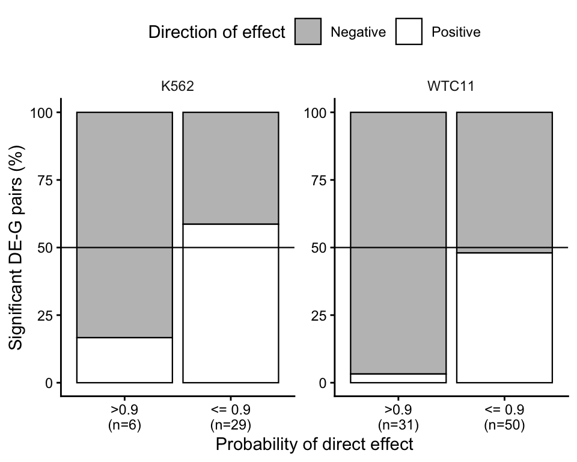

```r
# transform to long format for plotting
pairs_p90_plot <- pairs_p90 %>%
  mutate(plot_label = paste0(p90, "\n(n=", significant, ")")) %>%
  select(cell_type, plot_label, prop_negative, prop_positive) %>%
  pivot_longer(cols = c(prop_negative, prop_positive), names_to = "Effect direction",
               values_to = "% significant pairs") %>%
  mutate(`Effect direction` = str_to_title(sub("prop_", "", `Effect direction`)))

# plot the proportion of negative vs positives based on probability to be a direct effect
ggplot(pairs_p90_plot, aes(x = fct_rev(plot_label), y = `% significant pairs`, fill = `Effect direction`)) +
  facet_wrap(~ cell_type, scales = "free", drop = TRUE) +
  geom_bar(stat = "identity", color = "black", linewidth = 0.4) +
  geom_hline(yintercept = 0.5, linewidth = 0.4) +
  labs(x = "Probability of direct effect", y = "Significant DE-G pairs (%)", fill = "Direction of effect") +
  scale_fill_manual(values = c(Negative = "grey75", Positive = "white")) +
  scale_y_continuous(labels = function(x) x * 100) +
  theme_classic() +
  theme(strip.background = element_blank(), legend.position = "top")
```

Plot proportions for both experiments combined.

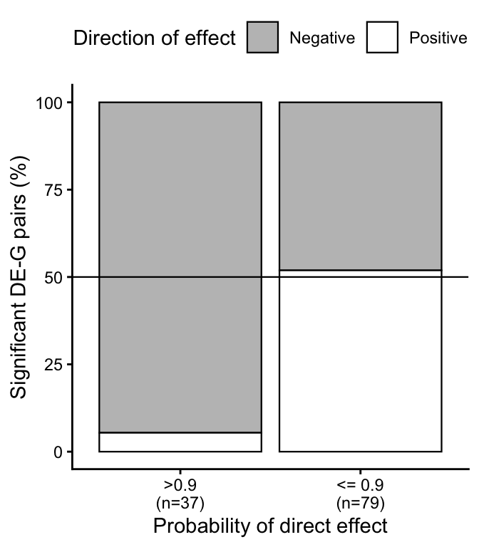

```r
# count number of significant pairs with positive and negative effects for pairs with direct vs
# indirect effect probability greater or lower than 0.9
pairs_p90_combined <- random_pairs %>%
  group_by(p90) %>%
  summarize(significant = sum(significant_wo_pos_controls_20fdr == TRUE),
            negative = sum(significant_wo_pos_controls_20fdr == TRUE & log_2_FC_effect_size <= 0),
            positive = sum(significant_wo_pos_controls_20fdr == TRUE & log_2_FC_effect_size > 0),
            prop_negative = negative / significant,
            prop_positive = positive / significant)

# transform to long format for plotting
pairs_p90_combined_plot <- pairs_p90_combined %>%
  mutate(plot_label = paste0(p90, "\n(n=", significant, ")")) %>%
  select(plot_label, prop_negative, prop_positive) %>%
  pivot_longer(cols = c(prop_negative, prop_positive), names_to = "Effect direction",
               values_to = "% significant pairs") %>%
  mutate(`Effect direction` = str_to_title(sub("prop_", "", `Effect direction`)))

# plot the proportion of negative vs positives based on probability to be a direct effect
ggplot(pairs_p90_combined_plot,
       aes(x = fct_rev(plot_label), y = `% significant pairs`, fill = `Effect direction`)) +
  geom_bar(stat = "identity", color = "black", linewidth = 0.4) +
  geom_hline(yintercept = 0.5, linewidth = 0.4) +
  labs(x = "Probability of direct effect", y = "Significant DE-G pairs (%)", fill = "Direction of effect") +
  scale_fill_manual(values = c(Negative = "grey75", Positive = "white")) +
  scale_y_continuous(labels = function(x) x * 100) +
  theme_classic() +
  theme(strip.background = element_blank(), legend.position = "top")
```

Alternatively, we can also look at this by plotting the observed CRISPR effect size on target gene expression as a function of probability to be direct vs. indirect effect.

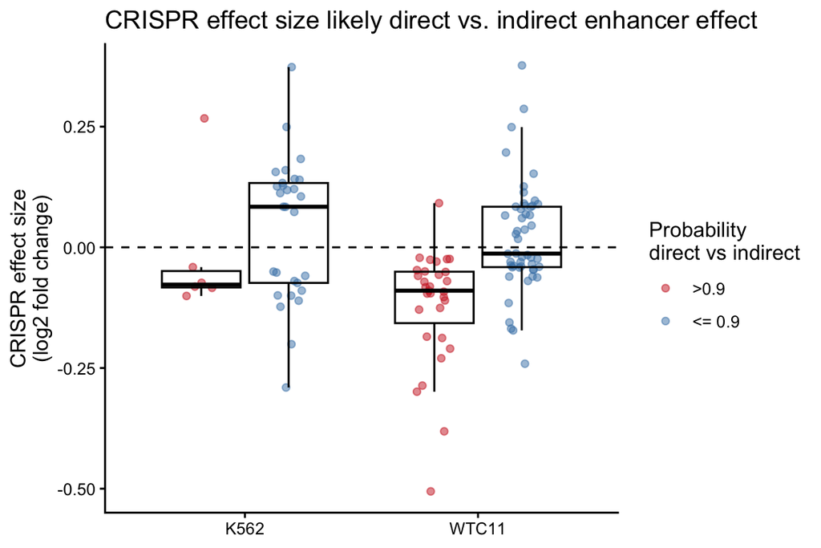

```r
# get all significant hits
random_pairs_hits <- filter(random_pairs, significant_wo_pos_controls_20fdr == TRUE)

# plot CRISPR effect size of likely direct vs. likely indirect effects
ggplot(random_pairs_hits, aes(x = cell_type, y = log_2_FC_effect_size, color = fct_rev(p90),
                                 group = interaction(cell_type, fct_rev(p90)))) +
  geom_hline(yintercept = 0, linetype = "dashed", linewidth = 0.5) +
  geom_point(alpha = 0.5, position = position_jitterdodge(jitter.width = 0.3)) +
  geom_boxplot(color = "black", fill = NA, outlier.shape = NA) +
  labs(title = "CRISPR effect size likely direct vs. indirect enhancer effect",
       y = "CRISPR effect size\n(log2 fold change)", color  = "Probability\ndirect vs indirect") +
  scale_color_manual(values = c(`>0.9` = "firebrick3", `<= 0.9` = "steelblue")) +
  theme_classic() +
  theme(axis.title.x = element_blank())
```